# Applied Research: Descriptive with R

### Scatterplot

Another visualization of data is provided by a scatterplot. We now can go ahead and create scatterplot that allow us to find whether or not there are relationships between variables, which that might suggest the need for further investigations.

Let’s look at a scatterplot of lotR fanship nd GoT fanship:

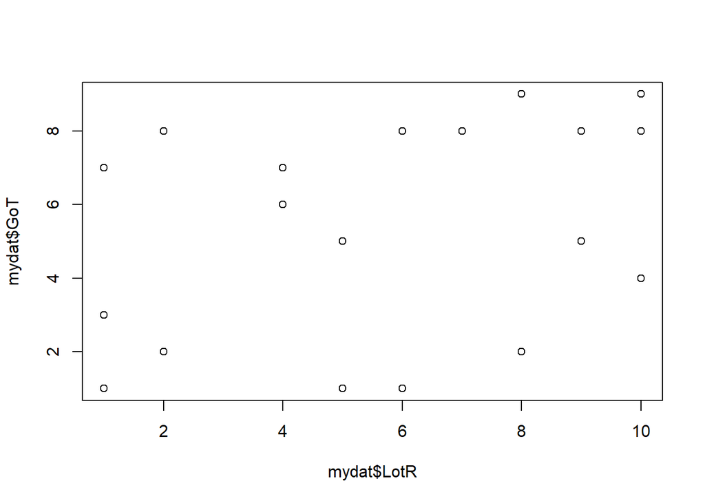

```r
plot(x = mydat$LotR, y = mydat$GoT)
```

How can you add a title to the plot? Change labels of the x and y axes?

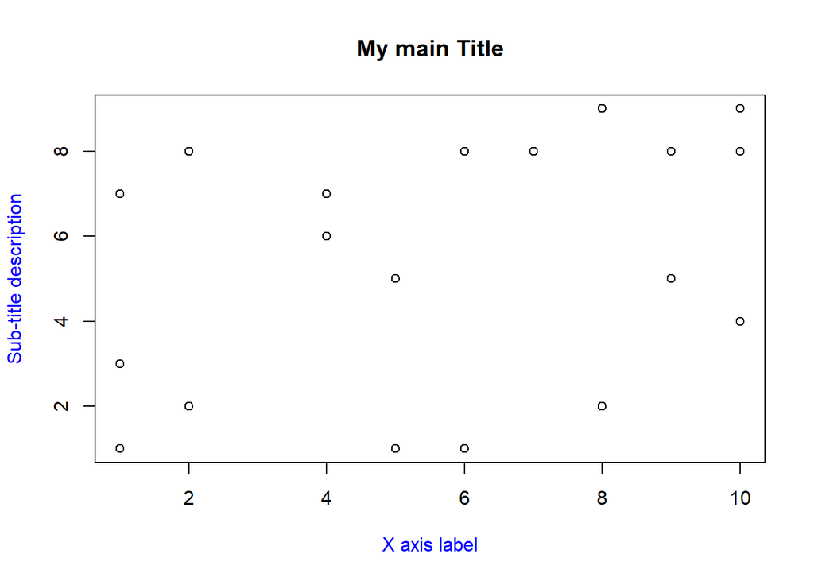

```r
plot(mydat$LotR, mydat$GoT,
     main= 'My main Title',
     xlab = 'X axis label',
     ylab = 'Sub-title description',
     col.lab = 'blue')
```

#### Exercise 21: Can you create a graph that shows the relationship between the variables `age` and `length` in mydat `datset`? Give some interpretations about the nature of the relationship between these two variables.

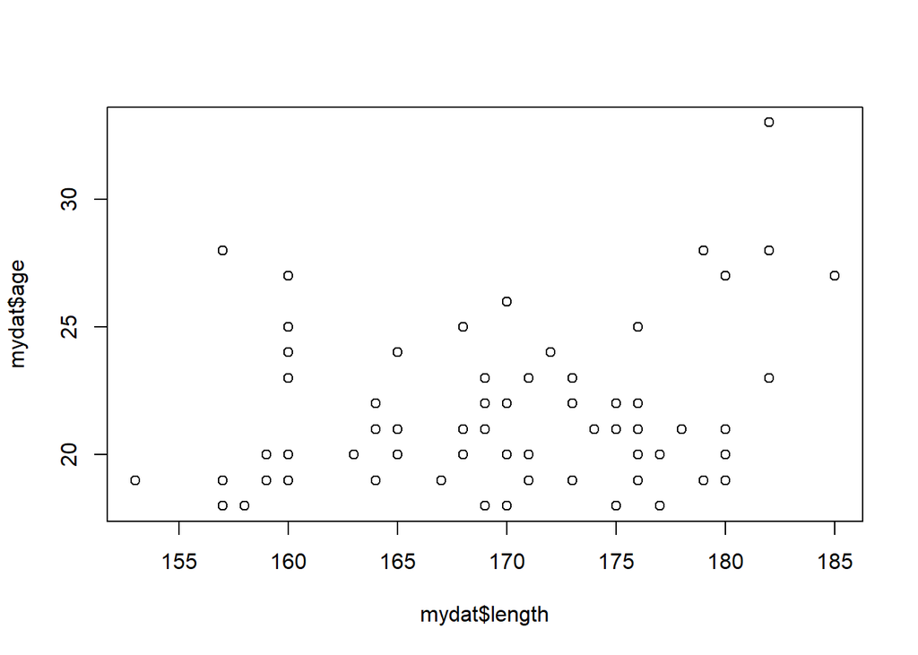

```r
plot(mydat$length, mydat$age)
```

You want to know how to make it fancier/ better?. Install the ggplot2 package and try it out!:

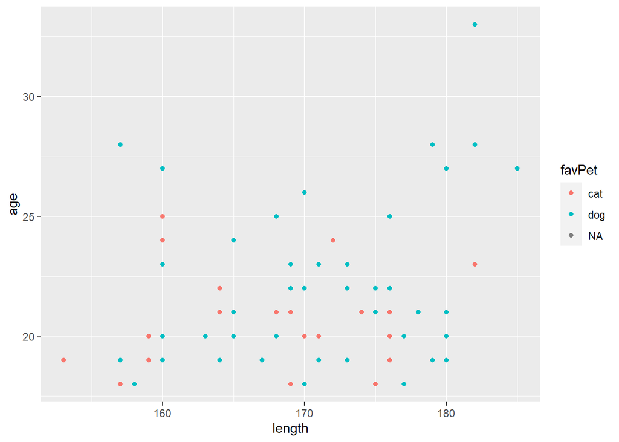

```r
# install.packages("ggplot2")
library(ggplot2)
ggplot(mydat, aes(x = length, y = age, color = favPet)) + geom_point()
```

## Apply your knowledge section

### Dataset1: Machine Learning Repository

https://archive.ics.uci.edu/ml/datasets.php

#### Q1: Can you please briefly evaluate the quality of your data? Please, apply data cleaning

process and remove the missing values or outliers.

#### Q2:Can you please create a boxplot in which x-axis are species type and y-axis is sepal.length variable? Interpret the graph. If needed, calculate the necessary statistics to support your conclusion.

#### Research Question: Does the association between pental.length and pental.width variables

vary between groups? Hint: create a plot showing the relationship between these variables among groups. Based on your plots, do you expect to find a relationship between the two variables? Does it vary among species?

```r
iris.uci <- read.csv(url("http://archive.ics.uci.edu/ml/machine-learning-databases/iris/iris.data"), header=FALSE, col.names=c("sepal.length","sepal.width","petal.length","petal.width","species"))

summary(iris.uci)
```

```
##   sepal.length    sepal.width     petal.length    petal.width
##  Min.   :4.300   Min.   :2.000   Min.   :1.000   Min.   :0.100
##  1st Qu.:5.100   1st Qu.:2.800   1st Qu.:1.600   1st Qu.:0.300
##  Median :5.800   Median :3.000   Median :4.350   Median :1.300
##  Mean   :5.843   Mean   :3.054   Mean   :3.759   Mean   :1.199
##  3rd Qu.:6.400   3rd Qu.:3.300   3rd Qu.:5.100   3rd Qu.:1.800
##  Max.   :7.900   Max.   :4.400   Max.   :6.900   Max.   :2.500
##             species
##  Iris-setosa    :50
##  Iris-versicolor:50
##  Iris-virginica :50
##
##
##
```

```r
str(iris.uci)
```

```
## 'data.frame':    150 obs. of  5 variables:
##  $ sepal.length: num  5.1 4.9 4.7 4.6 5 5.4 4.6 5 4.4 4.9 ...
##  $ sepal.width : num  3.5 3 3.2 3.1 3.6 3.9 3.4 3.4 2.9 3.1 ...
##  $ petal.length: num  1.4 1.4 1.3 1.5 1.4 1.7 1.4 1.5 1.4 1.5 ...
##  $ petal.width : num  0.2 0.2 0.2 0.2 0.2 0.4 0.3 0.2 0.2 0.1 ...
##  $ species     : Factor w/ 3 levels "Iris-setosa",..: 1 1 1 1 1 1 1 1 1 1 ...
```

[figure not shown]

```r
boxplot(sepal.length ~ species, data = iris.uci, main = "Iris Data", xlab = "length", ylab="Species", col = (c('blue','red','green')))
```

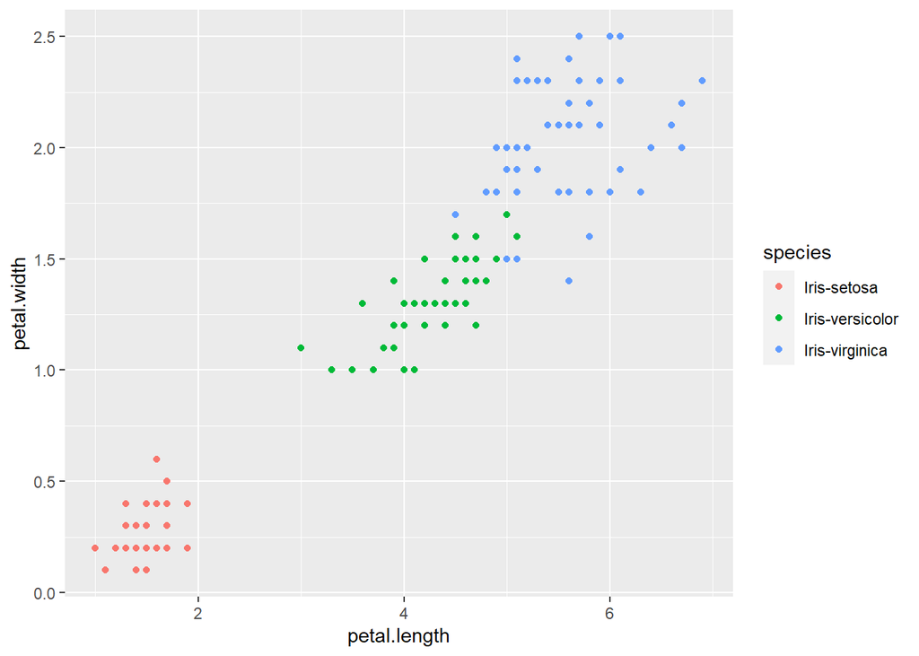

```r
ggplot(data = iris.uci,aes(x = petal.length, y = petal.width, colour = species)) +
      geom_point()
```

### Dataset 2: ACTG 175 Clinical trial

ACTG 175 was a randomized clinical trial to compare monotherapy with zidovudine or didanosine with combination therapy with zidovudine and didanosine or zidovudine and zalcitabine in adults infected with the human immunodeficiency virus type I whose CD4 T cell counts were between 200 and 500 per cubic millimeter. The trial is documented in Hammer SM, et al. (1996), “A trial comparing nucleoside monotherapy with combination therapy in HIV-infected adults with CD4 cell counts from 200 to 500 per cubic millimeter.”, New England Journal of Medicine, 335:1081–1090. The full publication can be found at https://www.nejm.org/doi/full/10.1056/NEJM199610103351501 You can download the dataset from here: https://raw.githubusercontent.com/carlosug/AppliedRR/master/data/trial_ACTG175.csv

#### Q1: Can you please conduct a very short data quality check? Please remove corrupt or inaccurate records from the data if necessary.

#### Q2: Can you give us a short description of the dataset?

Hint: Give us the number of total patients, gender distribution, and compute age statistics as mean, variance or standard deviation

#### Research Question: Is there a correlation between a patient’s age and their CD4 T cell count at baseline?

```r
url1 <- "https://raw.githubusercontent.com/carlosug/AppliedRR/master/data/trial_ACTG175.csv"
ACTG175 <- read.delim(url1,dec = '.',sep = ',')

str(ACTG175)
```

```
## 'data.frame':    2139 obs. of  13 variables:
##  $ patient_id  : int  10056 10059 10089 10093 10124 10140 10165 10190 10198 10229 ...
##  $ molecule    : Factor w/ 4 levels "Didanosine","Zidovudine",..: 4 1 1 1 2 3 2 2 1 2 ...
##  $ days        : int  948 1002 961 1166 1090 1181 794 957 198 188 ...
##  $ age         : int  48 61 45 47 43 46 31 41 40 35 ...
##  $ weight_kg   : num  89.8 49.4 88.5 85.3 66.7 ...
##  $ drug_history: Factor w/ 2 levels "No","Yes": 1 1 2 1 1 2 1 2 1 1 ...
##  $ race        : Factor w/ 2 levels "Non-White","White": 2 2 2 2 2 2 2 2 2 2 ...
##  $ gender      : Factor w/ 2 levels "Female","Male": 1 1 2 2 2 2 2 2 2 2 ...
##  $ symptomatic : Factor w/ 2 levels "Asymptomatic",..: 1 1 1 1 1 1 1 1 2 1 ...
##  $ cd4_baseline: int  422 162 326 287 504 235 244 401 214 221 ...
##  $ cd4_96_weeks: int  660 NA 122 NA 660 264 106 453 8 NA ...
##  $ cd8_baseline: int  566 392 2063 1590 870 860 708 889 652 221 ...
##  $ cd8_20_weeks: int  324 564 1893 966 782 1060 699 720 131 759 ...
```

```r
summary(ACTG175)
```

```
##    patient_id                           molecule        days
##  Min.   : 10056   Didanosine                :561   Min.   :  14.0
##  1st Qu.: 81447   Zidovudine                :532   1st Qu.: 727.0
##  Median :190566   zidovudine and Didanosine :522   Median : 997.0
##  Mean   :248778   Zidovudine and Zalcitabine:524   Mean   : 879.1
##  3rd Qu.:280277                                    3rd Qu.:1091.0
##  Max.   :990077                                    Max.   :1231.0
##
##       age          weight_kg      drug_history        race         gender
##  Min.   :12.00   Min.   : 31.00   No :1858     Non-White: 617   Female: 368
##  1st Qu.:29.00   1st Qu.: 66.68   Yes: 281     White    :1522   Male  :1771
##  Median :34.00   Median : 74.39
##  Mean   :35.25   Mean   : 75.13
##  3rd Qu.:40.00   3rd Qu.: 82.56
##  Max.   :70.00   Max.   :159.94
##
##        symptomatic    cd4_baseline     cd4_96_weeks     cd8_baseline
##  Asymptomatic:1769   Min.   :   0.0   Min.   :   0.0   Min.   :  40.0
##  Symptomatic : 370   1st Qu.: 263.5   1st Qu.: 209.2   1st Qu.: 654.0
##                      Median : 340.0   Median : 321.0   Median : 893.0
##                      Mean   : 350.5   Mean   : 328.6   Mean   : 986.6
##                      3rd Qu.: 423.0   3rd Qu.: 440.0   3rd Qu.:1207.0
##                      Max.   :1199.0   Max.   :1190.0   Max.   :5011.0
##                                       NA's   :797
##   cd8_20_weeks
##  Min.   : 124.0
##  1st Qu.: 631.5
##  Median : 865.0
##  Mean   : 935.4
##  3rd Qu.:1146.5
##  Max.   :6035.0
##
```

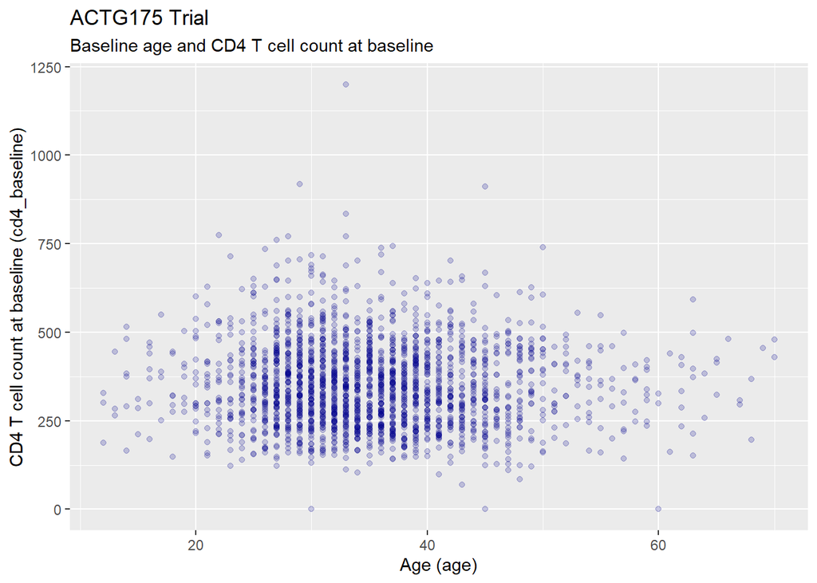

```r
ggplot(data = ACTG175, mapping = aes(x = age, y = cd4_baseline)) +
      geom_point(alpha = .2, col = "darkblue") +
  labs(title = "ACTG175 Trial",
       subtitle = "Baseline age and CD4 T cell count at baseline ",
       x = "Age (age)",
       y = "CD4 T cell count at baseline (cd4_baseline)")
```

### Human Origin, the evolution of modern human in Europe

```r
library(gsheet)
url <- 'https://docs.google.com/spreadsheets/d/1F6vp2tA3Q1FuFCOtw0d5XeZvJWRtEbg9chpmjKOtROQ/edit?ts=5ea70851#gid=2097240761'
if(requireNamespace('readr', quietly=TRUE)){
library(readr)
humano <- read_csv(construct_download_url(url),trim_ws = T)
}
head(humano, 10)
```

| Name | PC1 | PC2 | PC3 | PC4 | Group |
| --- | --- | --- | --- | --- | --- |
| Yuk_009 | 0.0123 | 0.1252 | 0.1147 | 0.0567 | Yukagir |
| Yuk_025 | 0.0120 | 0.1258 | 0.1168 | 0.0576 | Yukagir |
| Yuk_022 | 0.0136 | 0.1303 | 0.1186 | 0.0564 | Yukagir |
| Yuk_020 | 0.0170 | 0.1278 | 0.1176 | 0.0584 | Yukagir |
| MC_40 | 0.0183 | 0.1226 | 0.1123 | 0.0537 | Chukchi |
| Yuk_024 | 0.0144 | 0.1271 | 0.1124 | 0.0584 | Yukagir |
| Yuk_023 | 0.0124 | 0.1348 | 0.1238 | 0.0642 | Yukagir |
| MC_16 | 0.0144 | 0.1266 | 0.1169 | 0.0541 | Chukchi |
| MC_15 | 0.0146 | 0.1250 | 0.1119 | 0.0559 | Chukchi |
| MC_18 | 0.0175 | 0.1238 | 0.1167 | 0.0523 | Chukchi |

Convert to factor the groups

```r
summarize(filter(humano, Group == 'Yukagir'),
          mean = mean(PC1, na.rm = TRUE),
          count = sum(humano$Group == 'Yukagir'))
```

| mean | count |
| --- | --- |
| 0.01693684 | 19 |

[figure not shown]

```r
humano$Group <- as.factor(humano$Group)
library(ggplot2)
ggplot(humano, aes(x = PC1, y = PC2, color = Group)) + geom_point()
```

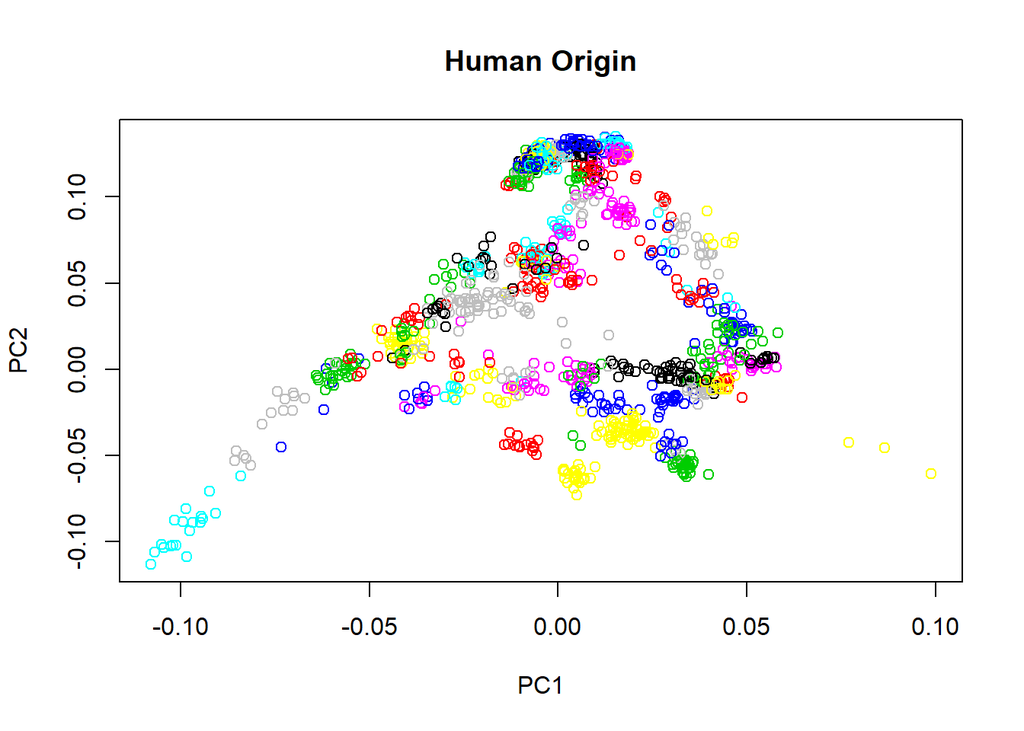

```r
plot(humano$PC1, humano$PC2,col = humano$Group,
     main= 'Human Origin',
     xlab = 'PC1',
     ylab = 'PC2',
     col.lab = 'black')
```

### Open data from ECDC COVID19

```r
#install.packages("utils")
library(utils)
data <- read.csv("https://opendata.ecdc.europa.eu/covid19/casedistribution/csv", na.strings = "", fileEncoding = "UTF-8-BOM")
library(dplyr)
str(data)
```

```
## 'data.frame':    17158 obs. of  11 variables:
##  $ dateRep                : Factor w/ 137 levels "01/01/2020","01/02/2020",..: 75 70 65 60 55 50 45 40 35 30 ...
##  $ day                    : int  15 14 13 12 11 10 9 8 7 6 ...
##  $ month                  : int  5 5 5 5 5 5 5 5 5 5 ...
##  $ year                   : int  2020 2020 2020 2020 2020 2020 2020 2020 2020 2020 ...
##  $ cases                  : int  113 259 280 285 369 255 215 171 168 330 ...
##  $ deaths                 : int  6 3 5 2 5 6 3 2 9 5 ...
##  $ countriesAndTerritories: Factor w/ 210 levels "Afghanistan",..: 1 1 1 1 1 1 1 1 1 1 ...
##  $ geoId                  : Factor w/ 210 levels "AD","AE","AF",..: 3 3 3 3 3 3 3 3 3 3 ...
##  $ countryterritoryCode   : Factor w/ 206 levels "ABW","AFG","AGO",..: 2 2 2 2 2 2 2 2 2 2 ...
##  $ popData2018            : int  37172386 37172386 37172386 37172386 37172386 37172386 37172386 37172386 37172386 37172386 ...
##  $ continentExp           : Factor w/ 6 levels "Africa","America",..: 3 3 3 3 3 3 3 3 3 3 ...
```

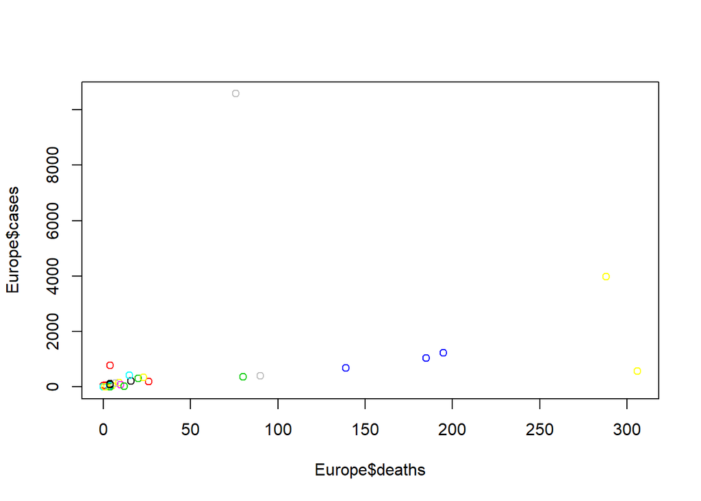

```r
Europe <- filter(data, dateRep == "05/05/2020", continentExp == "Europe")
plot(Europe$deaths, Europe$cases, col = Europe$countriesAndTerritories)
```

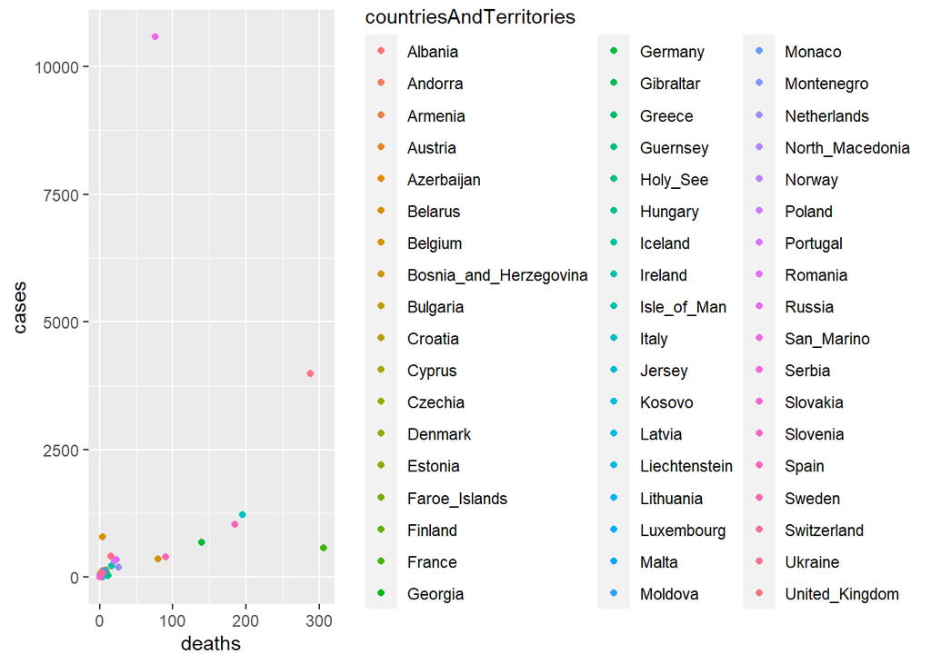

```r
ggplot(Europe, aes(x = deaths, y = cases, color = countriesAndTerritories)) + geom_point()
```

### Writting our own functions

At some point, you will want to write a function, and it will probably be sooner than you think. Functions are core to the way that R works, and the sooner that you get comfortable writing them, the sooner you’ll be able to leverage R’s power, and start having fun with it.

We will learn how to create functions for `mean`, `variance` and `standard deviation`. This section is particularlly tricky since our dataset is full of `NA`. Then, the code will be a little bit more complex than usual:

Start by writting the mean_age function into your script:

```r
my_mean <- function(x) {
  n = length(x[!is.na(x)])
  average <- sum((x),na.rm = TRUE)/n
  return(average)
}
my_mean(mydat$age)
```

```
## [1] 21.64179
```

In order to check whether your own function works properly, compare your results to with the `mean()` function alike:

```r
my_mean(mydat$age) == mean(mydat$age, na.rm = TRUE)
```

```
## [1] TRUE
```

If you get `TRUE` then means we are doing very well.

#### Exercise Bonus: Can you use our function called `my_mean()` to compute the `length` mean and check if you get same results as with `mean(mydat$length, na.rm = TRUE)`?.

```r
my_mean(mydat$length)
```

```
## [1] 169.8955
```

```r
my_mean(mydat$length) == mean(mydat$length, na.rm = TRUE)
```

```
## [1] TRUE
```

Then, we will perform similar work for variance and standard deviation.

For the variance:

```r
my_var <- function(x){
  n <-length((x[!is.na(x)]))
  m <-mean(x, na.rm = TRUE)
  (1/(n - 1)) * sum((x - m)^2, na.rm = TRUE)
}
```

#### Exercise Bonus: Can you use our function called `my_var()` to compute the `length` variance and check if you get same results as with `var(mydat$length, na.rm = TRUE)`?.

```r
my_var(mydat$length)
```

```
## [1] 61.06468
```

```r
my_var(mydat$length) == var(mydat$length, na.rm = TRUE)
```

```
## [1] TRUE
```

Now that you already master how to write functions, do make similar work for the standard deviation.

#### Exercise Bonus: Write your own function that computes the standard deviation of `age` in the `mydat` data set. Remember to add specification for dealing with NA:

Solution with NA:

```r
sd(mydat$age, na.rm = TRUE)
```

```
## [1] 3.048604
```

```r
# standard deviation

my_stdv <- function(x){
  n <- length((x[!is.na(x)]))
  m <- mean(x, na.rm = TRUE)
  v <- sum((x-m)^2,na.rm = TRUE)/(n-1)
  sqrt(v)
}
my_stdv(mydat$age)
```

```
## [1] 3.048604
```

Well done! You have done one of the most challenging part of R.